# CARE secondary parotid tumours

```r
pacman::p_load(tidyverse,
               gtsummary,
               dlookr,
               santoku, # to break variables
               DescTools, # for agreement
               irr, # for agreement
               janitor)
```

For wordcloud

```r
pacman::p_load(wordcloud, # word-cloud generator
               SnowballC, # for text stemming
               RColorBrewer, # palette
               wordcloud2,
               tm) # for text mining
```

```r
theme_set(theme_minimal())
```

# Dataset

```r
df <- read_csv("https://docs.google.com/spreadsheets/d/e/2PACX-1vRKPzFe2lbF87DNe9SBjuaIb5iMb4nCmgvfdyT4v-NjK-BZBR-HkUIUdgiML3t30EqQ1RCep0sExatK/pub?output=csv")
```

```r
names(df)
```

```
 [1] "Laika zīmogs"
 [2] "TITLE"
 [3] "Reviewer"
 [4] "AUTHORS"
 [5] "JOURNAL"
 [6] "YEAR published"
 [7] "Number of patients"
 [8] "Main focus of the report"
 [9] "Copy and paste the abstract"
[10] "Country of the correspondence author"
[11] "CARE Appraisal [Title 1 The diagnosis or intervention of primary focus followed by the words “case report”]"
[12] "CARE Appraisal [Key Words 2 2 to 5 key words that identify diagnoses or interventions in this case report, including \"case report\"]"
[13] "CARE Appraisal [Abstract 3a Introduction: What is unique about this case and what does it add to the scientific literature?]"
[14] "CARE Appraisal [Abstract 3b Main symptoms and/or important clinical findings]"
[15] "CARE Appraisal [Abstract 3c The main diagnoses, therapeutic interventions, and outcomes]"
```

[output cut: 32 more lines]

For the wordcloud later

```r
text <- df$`Copy and paste the abstract`
```

```r
dlookr::diagnose(df)
```

| variables | types | missing_count | missing_percent | unique_count | unique_rate |
| --- | --- | --- | --- | --- | --- |
| Laika zīmogs | character | 0 | 0.0000000 | 204 | 1.000000000 |
| TITLE | character | 0 | 0.0000000 | 105 | 0.514705882 |
| Reviewer | character | 0 | 0.0000000 | 3 | 0.014705882 |
| AUTHORS | character | 0 | 0.0000000 | 128 | 0.627450980 |
| JOURNAL | character | 0 | 0.0000000 | 76 | 0.372549020 |
| YEAR published | numeric | 0 | 0.0000000 | 38 | 0.186274510 |
| Number of patients | numeric | 0 | 0.0000000 | 7 | 0.034313725 |
| Main focus of the report | character | 0 | 0.0000000 | 4 | 0.019607843 |
| Copy and paste the abstract | character | 0 | 0.0000000 | 175 | 0.857843137 |
| Country of the correspondence author | character | 0 | 0.0000000 | 23 | 0.112745098 |

[output cut: 37 more lines]

```r
df <- df %>%
  mutate(JOURNAL = str_to_title(JOURNAL)) %>% # change the capitalization
  mutate(JOURNAL = str_trim(JOURNAL, side = c("both"))) %>% # remove spaces
  mutate(JOURNAL = str_replace(JOURNAL, "Resaerch", "Research"))  %>%
  mutate(JOURNAL = str_replace(JOURNAL, "Otolaryngology-Head And Neck Surgery", "Otolaryngology–Head And Neck Surgery")) %>%
  mutate(JOURNAL = str_replace(JOURNAL, "Otolaryngology–Head And Neck Surgery", "Archives Of Otolaryngology--Head & Neck Surgery")) %>%
  mutate(JOURNAL = str_replace(JOURNAL, "The Journal Of Laryngology & Otology", "The Journal Of Laryngology And Otology"))
```

# Check agreement

How many raters?

```r
df %>%
  tabyl(Reviewer)
```

```
 Reviewer   n     percent
       IA 101 0.495098039
       PJ 101 0.495098039
       SU   2 0.009803922
```

## Kappa

```r
df %>%
  select(Reviewer, ID,  `CARE Appraisal [Abstract 3b Main symptoms and/or important clinical findings]`:`CARE Appraisal [Key Words 2 2 to 5 key words that identify diagnoses or interventions in this case report, including "case report"]`) %>% # leave only the relevant columns
  filter(Reviewer != "SU") %>%  # remove SU from the rater

  # now reshape the dataset to obtain three columns
  pivot_longer(-c(Reviewer, ID),
               names_to = "Care_item",
               values_to = "Care_values") %>%
  select(-c(Care_item)) %>%

  # now reshape again to obtains the values per rater
  pivot_wider(id_cols = ID,
              names_from = Reviewer,
              values_from = Care_values) %>%
  tidyr::unnest() %>%  # this is to recover the values, check shorturl.at/gpAG3
  filter(!is.na(IA)) %>%
  filter(!is.na(PJ)) %>%
  select(-ID) %>%
  kappam.fleiss(., detail=TRUE)
```

```
 Fleiss' Kappa for m Raters

 Subjects = 267
   Raters = 2
    Kappa = 0.715

        z = 11.7
  p-value = 0

     Kappa      z p.value
No   0.715 11.681   0.000
Yes  0.715 11.681   0.000
```

**The kappa between the rater is .715**

Since they are comparable, I will leave only one + SU

```r
df <- df %>%
  filter(Reviewer %in% c('IA', 'SU'))
```

## add a continent column

```r
countries <- read_csv("https://raw.githubusercontent.com/dbouquin/IS_608/master/NanosatDB_munging/Countries-Continents.csv")
glimpse(countries)
```

```
Rows: 194
Columns: 2
$ Continent <chr> "Africa", "Africa", "Africa", "Africa", "Africa", "Africa", "Africa", "Africa", "Africa", "Africa", "Africa", "Africa", "Africa", "Africa", "Africa", "Africa", "Africa", "Africa", "Africa", "Africa", "Afric…
$ Country   <chr> "Algeria", "Angola", "Benin", "Botswana", "Burkina", "Burundi", "Cameroon", "Cape Verde", "Central African Republic", "Chad", "Comoros", "Congo", "Congo, Democratic Republic of", "Djibouti", "Egypt", "Equat…
```

```r
df <- df %>%
  mutate(`Country of the correspondence author` = (str_replace_all(`Country of the correspondence author`, "United States", "US"))) %>%
left_join(., countries, by = c("Country of the correspondence author" = "Country")) %>%
  mutate(Continent = case_when(
    `Country of the correspondence author` == "Taiwan" ~ "Asia",
    `Country of the correspondence author` == "Australia" ~ "Oceania",
    `Country of the correspondence author` == "Canada" ~ "North America",
    `Country of the correspondence author` == "China" ~ "Asia",
    `Country of the correspondence author` == "India" ~ "Asia",
    `Country of the correspondence author` == "Japan" ~ "Asia",
    `Country of the correspondence author` == "Israel" ~ "Asia",
    `Country of the correspondence author` == "Kuwait" ~ "Asia",
    `Country of the correspondence author` == "Morocco" ~ "Africa",
    `Country of the correspondence author` == "Qatar" ~ "Asia",
    `Country of the correspondence author` == "Tunisia" ~ "Africa",
    TRUE ~ "Europe"
  ))
```

```r
rm(countries)
```

# EDA

|  | Nr | ColName | Class | NAs | Levels |
| --- | --- | --- | --- | --- | --- |
| 1 | 1 | Reviewer | character | . |  |
| 2 | 2 | JOURNAL | character | . |  |
| 3 | 3 | YEAR published | numeric | . |  |
| 4 | 4 | Country of the correspondence author | character | . |  |
| 5 | 5 | Number of patients | numeric | . |  |

```
--------------------------------------------------------------------------------------------------------------------------------------------------------------------------------------------------------------------------------
Describe . (tbl_df, tbl, data.frame):

data frame: 103 obs. of  5 variables
        103 complete cases (100.0%)



--------------------------------------------------------------------------------------------------------------------------------------------------------------------------------------------------------------------------------
1 - Reviewer (character - dichotomous)

  length      n    NAs unique
     103    103      0      2
         100.0%   0.0%

    freq   perc  lci.95  uci.95'
IA   101  98.1%   93.2%   99.5%
SU     2   1.9%    0.5%    6.8%

' 95%-CI (Wilson)

--------------------------------------------------------------------------------------------------------------------------------------------------------------------------------------------------------------------------------
2 - JOURNAL (character)

  length      n    NAs unique levels  dupes
     103    103      0     68     68      y
         100.0%   0.0%
```

| level | freq | perc | cumfreq | cumperc |
| --- | --- | --- | --- | --- |
| Diagnostic Cytopathology | 7 | 6.8% | 7 | 6.8% |
| Journal Of Oral And Maxillofacial Surgery | 6 | 5.8% | 13 | 12.6% |
| The Journal Of Laryngology And Otology | 6 | 5.8% | 19 | 18.4% |
| British Medical Journal Case Report | 4 | 3.9% | 23 | 22.3% |
| Archives Of Otolaryngology--Head & Neck Surgery | 3 | 2.9% | 26 | 25.2% |
| European Archives Of Oto-Rhino-Laryngology | 3 | 2.9% | 29 | 28.2% |
| Head And Neck | 3 | 2.9% | 32 | 31.1% |
| The Laryngoscope | 3 | 2.9% | 35 | 34.0% |
| Acta Cytologica | 2 | 1.9% | 37 | 35.9% |
| British Journal Of Oral And Maxillofacial Surgery | 2 | 1.9% | 39 | 37.9% |

[output cut: 2 more lines]

```
... etc.
 [list output truncated]
```

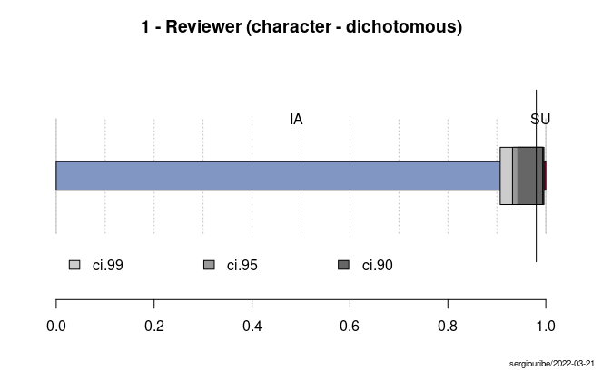

```
--------------------------------------------------------------------------------------------------------------------------------------------------------------------------------------------------------------------------------
3 - YEAR published (numeric)

    length         n       NAs    unique        0s      mean    meanCI'
       103       103         0        38         0  2'006.28  2'004.09
              100.0%      0.0%                0.0%            2'008.48

       .05       .10       .25    median       .75       .90       .95
  1'984.20  1'989.00  2'001.00  2'009.00  2'014.50  2'019.00  2'020.00

     range        sd     vcoef       mad       IQR      skew      kurt
     46.00     11.24      0.01     10.38     13.50     -0.81     -0.22

lowest : 1'976.0, 1'979.0, 1'981.0, 1'982.0 (2), 1'984.0
highest: 2'018.0 (2), 2'019.0 (4), 2'020.0 (4), 2'021.0 (4), 2'022.0

' 95%-CI (classic)
```

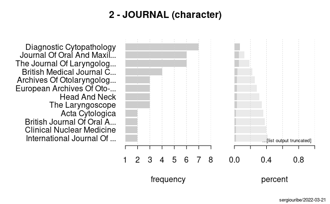

```
--------------------------------------------------------------------------------------------------------------------------------------------------------------------------------------------------------------------------------
4 - Country of the correspondence author (character)

  length      n    NAs unique levels  dupes
     103    103      0     23     23      y
         100.0%   0.0%
```

| level | freq | perc | cumfreq | cumperc |
| --- | --- | --- | --- | --- |
| US | 31 | 30.1% | 31 | 30.1% |
| United Kingdom | 12 | 11.7% | 43 | 41.7% |
| China | 7 | 6.8% | 50 | 48.5% |
| India | 7 | 6.8% | 57 | 55.3% |
| Italy | 7 | 6.8% | 64 | 62.1% |
| Turkey | 6 | 5.8% | 70 | 68.0% |
| Germany | 5 | 4.9% | 75 | 72.8% |
| Spain | 5 | 4.9% | 80 | 77.7% |
| Japan | 3 | 2.9% | 83 | 80.6% |
| Australia | 2 | 1.9% | 85 | 82.5% |

[output cut: 2 more lines]

```
... etc.
 [list output truncated]
```

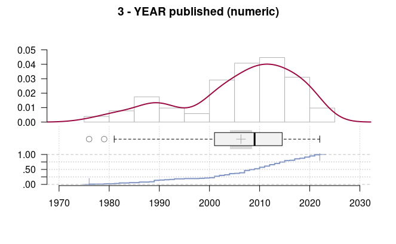

```
--------------------------------------------------------------------------------------------------------------------------------------------------------------------------------------------------------------------------------
5 - Number of patients (numeric)

  length       n    NAs  unique    0s  mean  meanCI'
     103     103      0       7     0  1.26    1.08
          100.0%   0.0%          0.0%          1.45

     .05     .10    .25  median   .75   .90     .95
    1.00    1.00   1.00    1.00  1.00  1.80    2.90

   range      sd  vcoef     mad   IQR  skew    kurt
    6.00    0.95   0.75    0.00  0.00  4.30   19.23
```

| level | freq | perc | cumfreq | cumperc |
| --- | --- | --- | --- | --- |
| 1 | 92 | 89.3% | 92 | 89.3% |
| 2 | 5 | 4.9% | 97 | 94.2% |
| 3 | 2 | 1.9% | 99 | 96.1% |
| 4 | 1 | 1.0% | 100 | 97.1% |
| 5 | 1 | 1.0% | 101 | 98.1% |
| 6 | 1 | 1.0% | 102 | 99.0% |
| 7 | 1 | 1.0% | 103 | 100.0% |

```
' 95%-CI (classic)
```

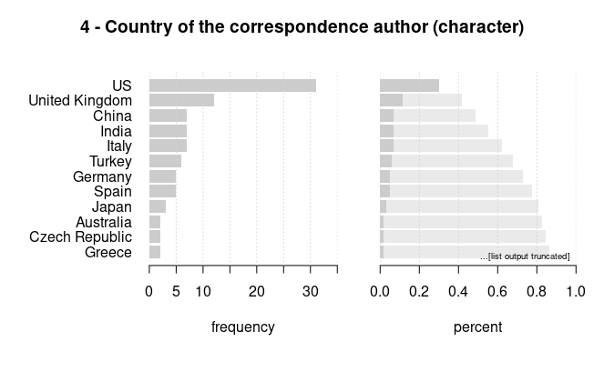

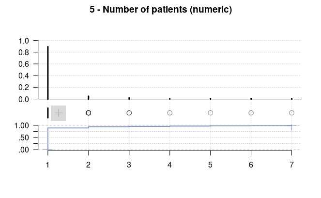

```r
df %>%
  select(Reviewer, JOURNAL, `YEAR published`, `Country of the correspondence author`, `Number of patients`) %>%
DescTools::Desc()
```

How many papers

```r
n_distinct(df$TITLE)
```

```
[1] 103
```

From how many journals?

```r
n_distinct(df$JOURNAL)
```

```
[1] 68
```

List of journals with at least 3 articles

```r
df %>%
  mutate(JOURNAL = fct_lump_min(JOURNAL, min = 3)) %>%
  count(JOURNAL) %>%
  arrange(desc(n))
```

| JOURNAL | n |
| --- | --- |
| Other | 68 |
| Diagnostic Cytopathology | 7 |
| Journal Of Oral And Maxillofacial Surgery | 6 |
| The Journal Of Laryngology And Otology | 6 |
| British Medical Journal Case Report | 4 |
| Archives Of Otolaryngology--Head & Neck Surgery | 3 |
| European Archives Of Oto-Rhino-Laryngology | 3 |
| Head And Neck | 3 |
| The Laryngoscope | 3 |

Patients distribution by paper

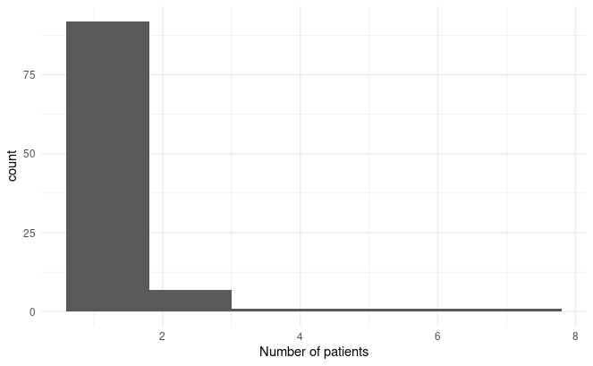

```r
df %>%
  ggplot(aes(x = `Number of patients`)) +
  geom_histogram(bins = 6)
```

How many patients per paper

```r
summary(df$`Number of patients`)
```

```
   Min. 1st Qu.  Median    Mean 3rd Qu.    Max.
  1.000   1.000   1.000   1.262   1.000   7.000
```

How many patients in total

```r
sum(df$`Number of patients`)
```

```
[1] 130
```

Males and females

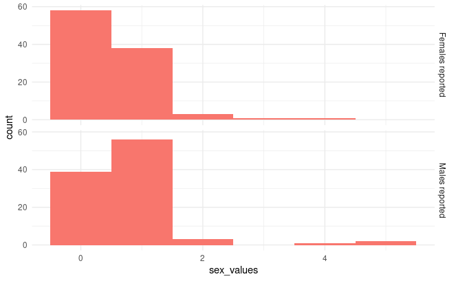

```r
df %>%
  pivot_longer(`Males reported`:`Females reported`,
               names_to = "sex",
               values_to = "sex_values") %>%
  ggplot(aes(x = sex_values,
             fill = "sex")) +

  geom_histogram(bins = 6) +
  facet_grid(sex ~ .) +
  theme(legend.position="none")
```

Year of publication

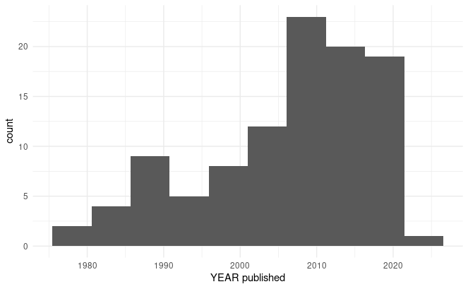

```r
df %>%
  ggplot(aes(x = `YEAR published`)) +
  geom_histogram(bins = 10)
```

Age of the patients

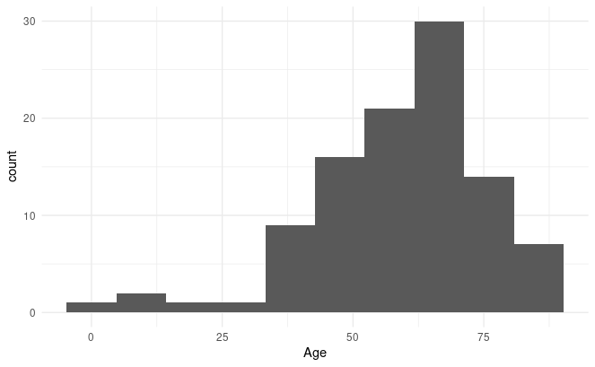

```r
df %>%
  ggplot(aes(Age)) +
  geom_histogram(bins = 10)
```

Age of the patients by sex

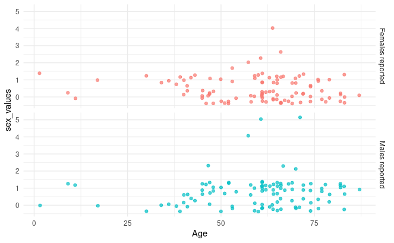

```r
df %>%
  pivot_longer(`Males reported`:`Females reported`,
               names_to = "sex",
               values_to = "sex_values") %>%
  ggplot(aes(y = sex_values,
             x = Age,
             color = sex)) +
  geom_jitter(alpha = .7) +
  facet_grid(sex ~ . ) +
  theme(legend.position="none")
```

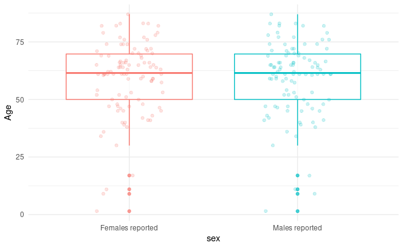

```r
df %>%
  pivot_longer(`Males reported`:`Females reported`,
               names_to = "sex",
               values_to = "sex_values") %>%
  ggplot(aes(y = Age,
             x = sex,
             color = sex)) +
  geom_boxplot(alpha = .7) +
  geom_jitter(alpha = .2, width = .2) +
  theme(legend.position="none")
```

Age by Continent

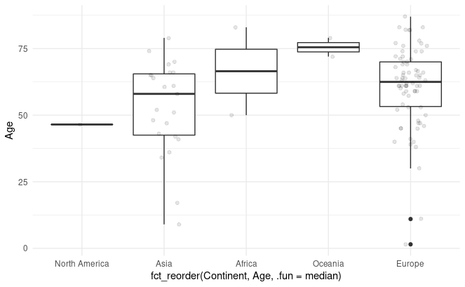

```r
df %>%
  distinct_at(vars(ID), .keep_all = TRUE) %>% # filter unique values
  ggplot(aes(x = fct_reorder(Continent, Age, .fun = median),
             y = Age)) +
  geom_boxplot() +
  geom_jitter(alpha = .1, width = 0.2)
```

Case reports by continent

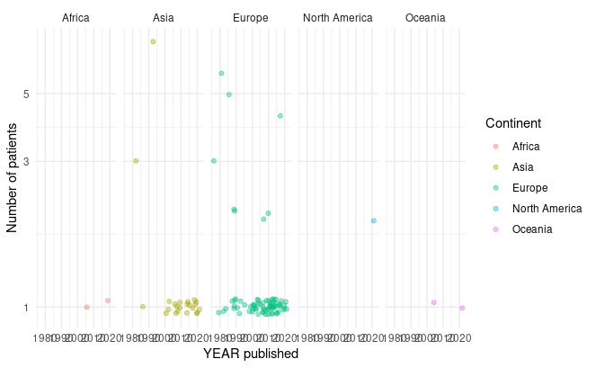

```r
df %>%
  distinct_at(vars(ID), .keep_all = TRUE) %>% # filter unique values
  group_by(Continent, `YEAR published`) %>%
  ggplot(aes(x = `YEAR published`,
             y = `Number of patients`,
             color = Continent))  +
  geom_jitter(alpha = .4) +
  scale_y_log10() +
  facet_grid(. ~ Continent)
```

# CARE ANALYSIS

Convert the answers to points

Yes = 1

Unclear = .1

No = 0

```r
df <- df %>%
  select(-c(TITLE, Reviewer, `Laika zīmogs`,
            AUTHORS, `Copy and paste the abstract`,
            Comments)) %>%
  # reshape the dataset
  pivot_longer(contains("CARE"),
               names_to = "CARE_item",
               values_to = "CARE_value") %>%
  # create a new column with the values of CARE
  mutate(CARE_value_num = case_when(
    CARE_value == "Yes" ~ "1",
    CARE_value == "Unclear" ~ "0.1",
    TRUE ~ "0"
  ))
```

## TABLE 1 CARE items compliance

Compliance per CARE item

```r
df %>%
  select(CARE_item, CARE_value) %>%
  mutate(CARE_item = fct_inorder(CARE_item)) %>% # reorder by appeareance
  gtsummary::tbl_summary(by = CARE_value,
                         percent = "row") %>%
  modify_header(update = list(
  label ~ '**Characteristic**',
  stat_1 ~ '**No**',
  stat_2 ~ '**Unclear**',
  stat_3 ~ '**Yes**'
))
```

| **Characteristic** | **No**<sup>1</sup> | **Unclear**<sup>1</sup> | **Yes**<sup>1</sup> |
| --- | --- | --- | --- |
| CARE_item |  |  |  |
| CARE Appraisal [Title 1 The diagnosis or intervention of primary focus followed by the words “case report”] | 66 (64%) | 0 (0%) | 37 (36%) |
| CARE Appraisal [Key Words 2 2 to 5 key words that identify diagnoses or interventions in this case report, including "case report"] | 102 (99%) | 0 (0%) | 1 (1.0%) |
| CARE Appraisal [Abstract 3a Introduction: What is unique about this case and what does it add to the scientific literature?] | 34 (33%) | 0 (0%) | 69 (67%) |
| CARE Appraisal [Abstract 3b Main symptoms and/or important clinical findings] | 37 (36%) | 1 (1.0%) | 65 (63%) |
| CARE Appraisal [Abstract 3c The main diagnoses, therapeutic interventions, and outcomes] | 55 (53%) | 0 (0%) | 48 (47%) |
| CARE Appraisal [Abstract 3d Conclusion—What is the main “take-away” lesson(s) from this case?] | 45 (44%) | 0 (0%) | 58 (56%) |
| CARE Appraisal [Introduction 4 One or two paragraphs summarizing why this case is unique (may include references)] | 13 (13%) | 0 (0%) | 90 (87%) |
| CARE Appraisal [Patient Information 5a De-identified patient specific information.] | 1 (1.0%) | 0 (0%) | 102 (99%) |
| CARE Appraisal [5b Primary concerns and symptoms of the patient.] | 3 (2.9%) | 0 (0%) | 100 (97%) |
| CARE Appraisal [5c Medical, family, and psycho-social history including relevant genetic information] | 100 (97%) | 0 (0%) | 3 (2.9%) |
| CARE Appraisal [5d Relevant past interventions with outcomes] | 34 (33%) | 0 (0%) | 69 (67%) |
| CARE Appraisal [Clinical Findings 6 Describe significant physical examination (PE) and important clinical findings.] | 2 (1.9%) | 0 (0%) | 101 (98%) |
| CARE Appraisal [Timeline 7 Historical and current information from this episode of care organized as a timeline] | 10 (9.7%) | 0 (0%) | 93 (90%) |
| CARE Appraisal [Diagnostic Assessment 8a Diagnostic testing (such as PE, laboratory testing, imaging, surveys).] | 2 (1.9%) | 0 (0%) | 101 (98%) |
| CARE Appraisal [Diagnostic Assessment 8b Diagnostic challenges (such as access to testing, financial, or cultural)] | 97 (94%) | 0 (0%) | 6 (5.8%) |
| CARE Appraisal [8c Diagnosis (including other diagnoses considered)] | 66 (64%) | 0 (0%) | 37 (36%) |
| CARE Appraisal [Therapeutic Intervention Diagnostic Assessment 8d Prognosis (such as staging in oncology) where applicable] | 71 (69%) | 1 (1.0%) | 31 (30%) |
| CARE Appraisal [Therapeutic Intervention 9a Types of therapeutic intervention (such as pharmacologic, surgical, preventive, self-care)] | 4 (3.9%) | 0 (0%) | 99 (96%) |
| CARE Appraisal [Therapeutic Intervention 9b Administration of therapeutic intervention (such as dosage, strength, duration)] | 72 (70%) | 0 (0%) | 31 (30%) |
| CARE Appraisal [Therapeutic Intervention 9c Changes in therapeutic intervention (with rationale)] | 26 (25%) | 0 (0%) | 77 (75%) |
| CARE Appraisal [Follow-up and Outcomes 10a Clinician and patient-assessed outcomes (if available).] | 35 (34%) | 1 (1.0%) | 67 (65%) |
| CARE Appraisal [Follow-up and Outcomes 10b Important follow-up diagnostic and other test results] | 26 (25%) | 1 (1.0%) | 76 (74%) |
| CARE Appraisal [Follow-up and Outcomes 10c Intervention adherence and tolerability (How was this assessed?)] | 81 (79%) | 2 (1.9%) | 20 (19%) |
| CARE Appraisal [Follow-up and Outcomes 10d Adverse and unanticipated events] | 21 (20%) | 0 (0%) | 82 (80%) |
| CARE Appraisal [Discussion 11a A scientific discussion of the strengths AND limitations associated with this case report] | 72 (70%) | 0 (0%) | 31 (30%) |
| CARE Appraisal [Discussion 11b Discussion of the relevant medical literature with references.] | 3 (2.9%) | 0 (0%) | 100 (97%) |
| CARE Appraisal [Discussion 11c The scientific rationale for any conclusions (including assessment of possible causes)] | 4 (3.9%) | 0 (0%) | 99 (96%) |
| CARE Appraisal [Discussion 11d The primary “take-away” lessons of this case report (without references) in a one paragraph conclusion] | 30 (29%) | 0 (0%) | 73 (71%) |
| CARE Appraisal [Patient Perspective 12 The patient should share their perspective in one to two paragraphs on the treatment(s) they received] | 103 (100%) | 0 (0%) | 0 (0%) |
| CARE Appraisal [Informed Consent 13 Did the patient give informed consent? Please provide if requested] | 3 (2.9%) | 90 (87%) | 10 (9.7%) |

<sup>*1*</sup> n (%)

Calculate the average quality per paper

```r
df_sum <- df %>%
  janitor::clean_names() %>% # convert the names
  mutate(care_value_num = as.double(care_value_num)) %>%  # change from chr to int
  select(id, care_item, care_value_num) %>% # select only some columns. Later need to join
  # reshapre the dataset
  pivot_wider(names_from = "care_item",
              values_from = "care_value_num") %>%
  relocate(id, .after = last_col()) %>%
  rowwise() %>%
  mutate(care_sum = sum(c_across(starts_with("care"))), .keep = "all") %>%
  ungroup() %>%
  select(ID = id, care_sum)
```

Now merge the df_sum

```r
df <- left_join(df, df_sum, by = "ID")
```

Remove the df_sum

```r
rm(df_sum)
```

## FIGURE 4 CARE score by year

Calculate the average quality per year

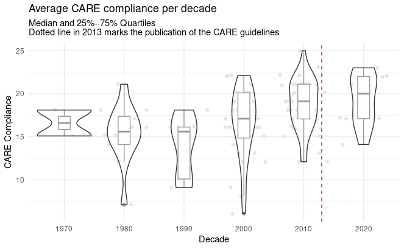

```r
df %>%
  # reshape
  mutate(Decade = floor(`YEAR published` / 10) * 10) %>%
  # mutate(Decade = santoku::chop(`YEAR published`, c(1969, 1979, 1989, 1999, 2009, 2019))) %>%
  pivot_wider(names_from = CARE_item,
              values_from = CARE_value) %>%
  distinct(., ID, .keep_all = TRUE) %>%  # filter unique IDs
  select(ID, Decade, care_sum) %>%
  ggplot(aes(x = as.factor(Decade),
             y = care_sum)) +
  geom_jitter(color = "grey90") +
  geom_boxplot(width = .2, color = "grey60") +
  geom_violin(width = .9, fill = NA) +
  labs(
    title = "Average CARE compliance per decade",
    subtitle = "Median and 25%−75% Quartiles\nDotted line in 2013 marks the publication of the CARE guidelines",
    y = "CARE Compliance",
    x = "Decade"
  ) +
  geom_vline(
    aes(xintercept = 5.3), linetype = "dashed", colour = "red", size = 0.5)
```

Quality by continent

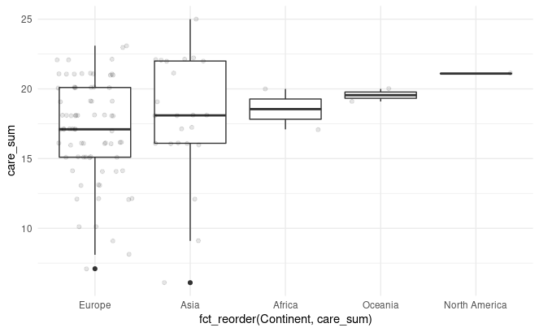

```r
df %>%
  distinct_at(vars(ID), .keep_all = TRUE) %>% # filter unique values, since there is the care_sum for each id
  ggplot(aes(x = fct_reorder(Continent, care_sum),
             y = care_sum)) +
  geom_boxplot() +
  geom_jitter(alpha = .1)
```

```r
NA
```

But keep in mind the n for each continent

```r
df %>%
  distinct_at(vars(ID), .keep_all = TRUE) %>% # filter unique values, since there is the care_sum for each id
  group_by(Continent) %>%
  summarise(n = n(), "Mean" = mean(care_sum), "sd" = sd(care_sum), min = min(care_sum), max = max(care_sum)) %>%
  mutate_if(is.numeric, round, 1)
```

| Continent | n | Mean | sd | min | max |
| --- | --- | --- | --- | --- | --- |
| Africa | 2 | 18.6 | 2.1 | 17.1 | 20.0 |
| Asia | 23 | 17.9 | 4.4 | 6.1 | 25.0 |
| Europe | 75 | 17.0 | 3.6 | 7.1 | 23.1 |
| North America | 1 | 21.1 | NA | 21.1 | 21.1 |
| Oceania | 2 | 19.6 | 0.6 | 19.1 | 20.0 |

Papers published by Year

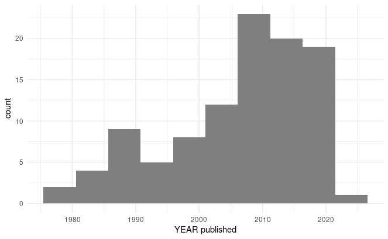

```r
df %>%

  distinct(., ID, .keep_all = TRUE) %>%   # filter unique IDs
  ggplot(aes(x = `YEAR published`)) +
  geom_histogram(bins = 10, fill = "grey50")
```

```r
NA
```

By country

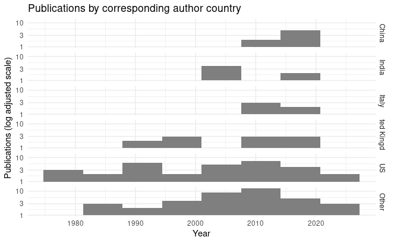

```r
df %>%

  distinct(., ID, .keep_all = TRUE) %>%   # filter unique IDs
  mutate(`Country of the correspondence author` = fct_lump_min(`Country of the correspondence author`, min = 7)) %>%
  ggplot(aes(x = `YEAR published`)) +
  geom_histogram(bins = 8, fill = "grey50") +
  facet_grid( `Country of the correspondence author` ~  .) +
  labs(title = "Publications by corresponding author country",
       x = "Year",
       y = "Publications (log adjusted scale)") +
  scale_y_log10()
```

```r
NA
```

papers publishes by year by continent

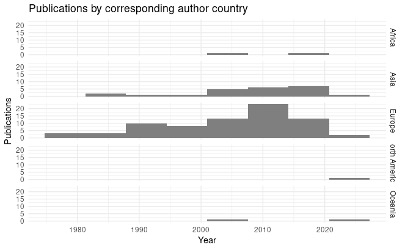

```r
df %>%

  distinct(., ID, .keep_all = TRUE) %>%   # filter unique IDs
  ggplot(aes(x = `YEAR published`)) +
  geom_histogram(bins = 8, fill = "grey50") +
  facet_grid( Continent ~  .) +
  labs(title = "Publications by corresponding author country",
       x = "Year",
       y = "Publications")
```

## create a new CARE simplified name items

```r
df <- df %>%
  mutate(CARE_name_simple = case_when(
    str_detect(CARE_item,"Title 1 The diagnosis")  ~ "01 Title",
    str_detect(CARE_item,"Key Words 2 2 to 5 key") ~ "02 Keywords",
    str_detect(CARE_item,"Abstract 3") ~ "03 Abstract",
    str_detect(CARE_item,"Introduction 4") ~ "04 Introduction",
    str_detect(CARE_item,"5") ~ "05 Patient Information",
    str_detect(CARE_item,"6") ~ "06 Clinical Findings",
    str_detect(CARE_item,"7") ~ "07 Timeline",
    str_detect(CARE_item,"8") ~ "08 Diagnostic Assessment",
    str_detect(CARE_item,"9") ~ "09 Therapeutic Intervention",
    str_detect(CARE_item,"10") ~ "10 Follow-up and Outcomes",
    str_detect(CARE_item,"11") ~ "11 Discussion",
    str_detect(CARE_item,"12") ~ "12 Patient Perspective",
    TRUE ~ "13 Informed Consent"
  ))
```

## Count CARE new items

```r
df %>%
  mutate(CARE_value = fct_relevel(CARE_value, "Yes", "Unclear")) %>%
  select(CARE_name_simple, CARE_value) %>%
  group_by(CARE_name_simple, CARE_value) %>%
  # count() %>%
  gtsummary::tbl_summary(by = CARE_value,
                         percent = "row") %>%
  modify_header(update = list(
  label ~ '**Characteristic**',
  stat_1 ~ '**Yes**',
  stat_2 ~ '**Unclear**',
  stat_3 ~ '**No**'
))
```

| **Characteristic** | **Yes**<sup>1</sup> | **Unclear**<sup>1</sup> | **No**<sup>1</sup> |
| --- | --- | --- | --- |
| CARE_name_simple |  |  |  |
| 01 Title | 37 (36%) | 0 (0%) | 66 (64%) |
| 02 Keywords | 1 (1.0%) | 0 (0%) | 102 (99%) |
| 03 Abstract | 240 (58%) | 1 (0.2%) | 171 (42%) |
| 04 Introduction | 90 (87%) | 0 (0%) | 13 (13%) |
| 05 Patient Information | 274 (67%) | 0 (0%) | 138 (33%) |
| 06 Clinical Findings | 101 (98%) | 0 (0%) | 2 (1.9%) |
| 07 Timeline | 93 (90%) | 0 (0%) | 10 (9.7%) |
| 08 Diagnostic Assessment | 175 (42%) | 1 (0.2%) | 236 (57%) |
| 09 Therapeutic Intervention | 207 (67%) | 0 (0%) | 102 (33%) |
| 10 Follow-up and Outcomes | 245 (59%) | 4 (1.0%) | 163 (40%) |
| 11 Discussion | 303 (74%) | 0 (0%) | 109 (26%) |
| 12 Patient Perspective | 0 (0%) | 0 (0%) | 103 (100%) |
| 13 Informed Consent | 10 (9.7%) | 90 (87%) | 3 (2.9%) |

<sup>*1*</sup> n (%)

# Analysis before and after 2013

Create a new var indicating if before or after

```r
df <- df %>%
  mutate(moment = case_when(
    `YEAR published` < 2013 ~ "Before",
    TRUE ~"After"
  ))
```

## Table 3

Now compare before and after

| **Characteristic** | **N** | **Beta** | **95% CI**<sup>1</sup> | **p-value** |
| --- | --- | --- | --- | --- |
| Moment |  |  |  |  |
| Before | 68 | — | — |  |
| After | 35 | 1.4 | -0.29, 3.1 | 0.10 |
| JOURNAL |  |  |  |  |
| Other | 68 | — | — |  |
| Archives Of Otolaryngology--Head & Neck Surgery | 3 | -2.3 | -6.6, 2.0 | 0.3 |
| British Medical Journal Case Report | 4 | 2.7 | -1.2, 6.6 | 0.2 |
| Diagnostic Cytopathology | 7 | -0.20 | -3.1, 2.6 | 0.9 |
| European Archives Of Oto-Rhino-Laryngology | 3 | 1.7 | -2.6, 6.0 | 0.4 |
| Head And Neck | 3 | -1.0 | -5.3, 3.2 | 0.6 |
| Journal Of Oral And Maxillofacial Surgery | 6 | 0.36 | -2.8, 3.5 | 0.8 |
| The Journal Of Laryngology And Otology | 6 | -2.8 | -6.0, 0.28 | 0.074 |
| The Laryngoscope | 3 | -2.4 | -6.7, 1.9 | 0.3 |
| Continent |  |  |  |  |
| Europe | 75 | — | — |  |
| Asia | 23 | 0.57 | -1.2, 2.4 | 0.5 |
| Other | 5 | 1.2 | -2.2, 4.6 | 0.5 |

<sup>*1*</sup> CI = Confidence Interval

# Wordcloud

```r
docs <- Corpus(VectorSource(text))
```

```r
docs <- docs %>%
  tm_map(removeNumbers) %>%
  tm_map(removePunctuation) %>%
  tm_map(stripWhitespace)
```

```r
# Convert the text to lower case
docs <- tm_map(docs, content_transformer(tolower))
# Remove numbers
docs <- tm_map(docs, removeNumbers)
# Remove english common stopwords
docs <- tm_map(docs, removeWords, stopwords("english"))
# specify your stopwords as a character vector
docs <- tm_map(docs, removeWords, c("keywords"))
# Remove punctuations
docs <- tm_map(docs, removePunctuation)
# Eliminate extra white spaces
docs <- tm_map(docs, stripWhitespace)
# Text stemming
# docs <- tm_map(docs, stemDocument)
```

```r
dtm <- TermDocumentMatrix(docs)
m <- as.matrix(dtm)
v <- sort(rowSums(m),decreasing=TRUE)
d <- data.frame(word = names(v),freq=v)
head(d, 10)
```

|  | word | freq |
| --- | --- | --- |
| parotid | parotid | 523 |
| gland | gland | 330 |
| carcinoma | carcinoma | 242 |
| metastatic | metastatic | 223 |
| case | case | 216 |
| metastasis | metastasis | 213 |
| cell | cell | 172 |
| primary | primary | 156 |
| patient | patient | 140 |
| metastases | metastases | 139 |

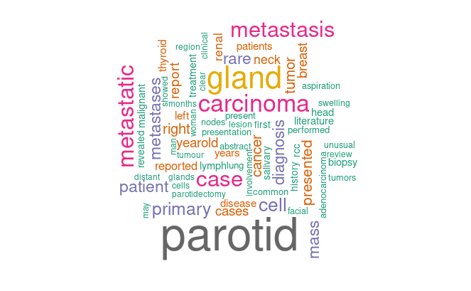

```r
set.seed(1234)
wordcloud(
  words = d$word,
  freq = d$freq,
  min.freq = 35,
  max.words = 200,
  random.order = TRUE,
  rot.per = 0.35,
  colors = brewer.pal(8, "Dark2")
)
```

# Ingus 1 march 2022

I: Agreement between Ingus and Peteris

S: what is the quality of the reports?

I: what is the quality before and after 2013

I: difference between journals